# A (fast) introduction to Python

(there is a whole lot more, but this should be enough to make us dangerous)

## Python is dynamically typed

```python
x = 5
```

```python
type(x)
```

```
int
```

```python
x = 'Foo'
```

```python
type(x)
```

```
str
```

### Basic types: numbers

```python
type(1)
```

```
int
```

```python
type(1.1)
```

```
float
```

```python
3 / 2
```

```
1.5
```

Python can 'promote' ints to floats

```python
1 * 2
```

```
2
```

```python
1.0 * 2
```

```
2.0
```

Numerical operators

```python
7 % 2
```

```
1
```

```python
3 // 2
```

```
1
```

```python
2 ** 123   # unbounded ints!
```

```
10633823966279326983230456482242756608
```

In-place operators

`A += B` means `A = A + B`

```python
a = 5
a += 6
a
```

```
11
```

Increment by one is just `a += 1`. There is no `a++`.

```python
a += 1
a
```

```
12
```

Comparisons

- `<`, `<=`, `>`, `>=` - less than, less or equal, greater than, greater or equal
- `==`, `!=` - equal, not equal (works for things other than numbers, too)
- `is`, `is not` - checks object identity (was it a second cat, or was it the *same cat*?)

```python
-5 < 10
```

```
True
```

```python
5 + 2 == 9 - 2
```

```
True
```

### Basic types: Booleans

```python
True
```

```
True
```

```python
False
```

```
False
```

Boolean operators: `and`, `or`, `not`

```python
5 < 3 or 3 > 2
```

```
True
```

```python
a = 1
b = 2
(a + b == 3) and not (a == 5)
```

```
True
```

(most) Python expressions perform automatic boolean coercion when asked. `bool(any_type_of_zero)` is `False`, everything else is `True`

```python
bool(0)
```

```
False
```

```python
bool(-1)  # or anything that is not zero
```

```
True
```

### `None` : Python's version of NULL

```python
a = None
a == None
```

```
True
```

more commonly...

```python
a is None
```

```
True
```

```python
a is not None
```

```
False
```

## Python has rich built-in collections

### Flexible strings: `str`

```python
a = 'This is a string'
b = "and so is this"
c = '''If I use the triple quotes,
I can extend my string over
multiple lines
'''
d = """Triple-up my double or my
triple quotes, Python doesn't care.
"""
```

```python
a
```

```
'This is a string'
```

```python
b
```

```
'and so is this'
```

```python
c
```

```
'If I use the triple quotes, \nI can extend my string over\nmultiple lines\n'
```

```python
print(c)
```

```
If I use the triple quotes,
I can extend my string over
multiple lines
```

```python
d
```

```
"Triple-up my double or my\ntriple quotes, Python doesn't care.\n"
```

You can create a new string out of a substring of an existing string using 'slicing'

```python
c[0]  # zero-based indexing
```

```
'I'
```

```python
c[0:3] # from index 0 to 3, not including 3
```

```
'If '
```

```python
c[:3]  # Python 'fills in' missing values
```

```
'If '
```

```python
c[-1]  # Index from the end, going backward
```

```
'\n'
```

```python
c[::2]  # From beginning to end, take every other letter
```

```
'I  s h rpeqoe,\n a xedm tigoe\nutpelns'
```

```python
'NaN' * 8 + ' Batman'   # Strings can be duplicated (*) and concatenated (+)
```

```
'NaNNaNNaNNaNNaNNaNNaNNaN Batman'
```

### Lists: dynamic types, dynamic sizes

```python
lst0 = [1, 2, 'foo', None]  # but we don't do this a lot
```

```python
lst1 = [2, 4, 8]
```

```python
lst0 + lst1
```

```
[1, 2, 'foo', None, 2, 4, 8]
```

List slicing works like string slicing (and you can also put list slices on the left-hand-side of assignments!)

```python
lst0[2]
```

```
'foo'
```

```python
lst0[:2]
```

```
[1, 2]
```

```python
lst0[:] = [1,2,3]  # effectively replaces the elements of lst0
lst0
```

```
[1, 2, 3]
```

```python
lst0.append('another item')
lst0
```

```
[1, 2, 3, 'another item']
```

```python
lst0 += lst1
lst0
```

```
[1, 2, 3, 'another item', 2, 4, 8]
```

Strings can be `.split` into lists:

```python
words = 'the quick brown fox jumps over the lazy dog'.split()
words
```

```
['the', 'quick', 'brown', 'fox', 'jumps', 'over', 'the', 'lazy', 'dog']
```

They can also be joined back together

```python
'--'.join(words)
```

```
'the--quick--brown--fox--jumps--over--the--lazy--dog'
```

### Tuples: like lists, but immutable

```python
1,2,3
```

```
(1, 2, 3)
```

```python
1,
```

```
(1,)
```

```python
()
```

```
()
```

```python
tup = 1,2,3,4,5,6,7
tup[2:5]
```

```
(3, 4, 5)
```

### Dictionaries: dynamic mappings between keys and values

Keys should generally be immutable, so numbers, strings and tuples are OK, but lists and `dict`s are not.

```python
sizes = {'tall': 12, 'grande': 16, 'venti': 20}
sizes
```

```
{'tall': 12, 'grande': 16, 'venti': 20}
```

```python
sizes['grande']
```

```
16
```

```python
sizes['trenta'] = 30
sizes
```

```
{'tall': 12, 'grande': 16, 'venti': 20, 'trenta': 30}
```

### Sets: like dictionaries, but if you only kept the keys

```python
s0 = {1, 2, 3}
s0
```

```
{1, 2, 3}
```

```python
s1 = {3, 4, 5}
s1
```

```
{3, 4, 5}
```

```python
s0 | s1  # set union
```

```
{1, 2, 3, 4, 5}
```

```python
s0 & s1 # set intersection
```

```
{3}
```

```python
s0 - s1  # set subtraction
```

```
{1, 2}
```

```python
s0 ^ s1  # set 'xor'
```

```
{1, 2, 4, 5}
```

### Common collection operations

All our collections support membership tests

```python
print(d)
```

```
Triple-up my double or my
triple quotes, Python doesn't care.
```

```python
'Python' in d   # substring check
```

```
True
```

```python
1 in [1,2,3]
```

```
True
```

```python
2 in (4,5,6)
```

```
False
```

```python
'quattro' in sizes
```

```
False
```

```python
s0
```

```
{1, 2, 3}
```

```python
2 in s0
```

```
True
```

### Getting the length

```python
len(d)
```

```
62
```

```python
len([1,2,3])
```

```
3
```

```python
len((4,5,6))
```

```
3
```

```python
len(sizes)
```

```
4
```

### Truthiness rule of collections

If the `len()` of a collection is zero, it is `False`-y. Otherwise it is truthy.

```python
len('')
```

```
0
```

```python
bool('')
```

```
False
```

```python
bool('True')
```

```
True
```

```python
bool('False')
```

```
True
```

```python
bool([])
```

```
False
```

## Python has the control structures you'd expect

(but we use colons and indentation to show blocks, which can be surprising)

if / elif / else

```python
customer_is_thirsty = True
low_on_coffee = False

if customer_is_thirsty:
    recommended_size = 'trenta'
elif low_on_coffee:
    recommended_size = 'tall'
else:
    recommended_size = 'grande'

print(recommended_size, '=>', sizes[recommended_size])
```

```
trenta => 30
```

while

```python
remaining_coffee = 72

while remaining_coffee >= 12:
    if remaining_coffee >= 20:
        size = 'venti'
    elif remaining_coffee >= 16:
        size = 'grande'
    else:
        size = 'tall'
    ozs = sizes[size]
    remaining_coffee -= ozs
    print(f'Serving a {size} of {ozs}oz, leaving {remaining_coffee}oz for others')
```

```
Serving a venti of 20oz, leaving 52oz for others
Serving a venti of 20oz, leaving 32oz for others
Serving a venti of 20oz, leaving 12oz for others
Serving a tall of 12oz, leaving 0oz for others
```

for loops iterate over a collection (like `for each` in other languages)

```python
size_keys = list(sizes)  # gets the keys
size_keys
```

```
['tall', 'grande', 'venti', 'trenta']
```

```python
for name in size_keys:
    print(name)
```

```
tall
grande
venti
trenta
```

If you *need* a sequence of numbers to use with a `for` loop, you can use the `range` function:

```python
for x in range(5):
    print(x)
```

```
0
1
2
3
4
```

```python
for x in range(10, 100, 5):
    print(x, end=' ')
```

```
10 15 20 25 30 35 40 45 50 55 60 65 70 75 80 85 90 95
```

## Comprehending comprehensions

Python makes building simple `list`s/`set`s/`dict`s easy

```python
lst = [x ** 2 for x in range(10)]
lst
```

```
[0, 1, 4, 9, 16, 25, 36, 49, 64, 81]
```

```python
grid = [(x, y) for x in range(4) for y in range(4)]
grid
```

```
[(0, 0),
 (0, 1),
 (0, 2),
 (0, 3),
 (1, 0),
 (1, 1),
 (1, 2),
 (1, 3),
 (2, 0),
 (2, 1),
 (2, 2),
 (2, 3),
 (3, 0),
 (3, 1),
 (3, 2),
 (3, 3)]
```

```python
matrix = [
    [(r, c) for c in range(5)]
    for r in range(5)
]
matrix
```

```
[[(0, 0), (0, 1), (0, 2), (0, 3), (0, 4)],
 [(1, 0), (1, 1), (1, 2), (1, 3), (1, 4)],
 [(2, 0), (2, 1), (2, 2), (2, 3), (2, 4)],
 [(3, 0), (3, 1), (3, 2), (3, 3), (3, 4)],
 [(4, 0), (4, 1), (4, 2), (4, 3), (4, 4)]]
```

It works with sets & dicts as well...

```python
{x: 100 for x in range(5)}
```

```
{0: 100, 1: 100, 2: 100, 3: 100, 4: 100}
```

## Simple functions

```python
def mysum(values):
    total = 0
    for value in values:
        total += value
    return total
```

```python
mysum([1,2,3,4,5,6,7,8,9,10])
```

```
55
```

```python
def myadd(x, y):
    return x + y
myadd(2, 40)
```

```
42
```

## Using modules and packages

A lot is built in to Python (called the 'builtins', actually), but if you need more, the `import` statement is used to make various libraries available to your program:

```python
import numpy as np   # imports the 'numpy' library and gives it the name 'np' in the current context
```

```python
np.array([1,2,3])
```

```
array([1, 2, 3])
```

```python
import numpy   # imports numpy and calls it numpy
```

```python
numpy.array([1,2,3])
```

```
array([1, 2, 3])
```

Libraries are organized into modules and 'packages' (groups of modules). Sometimes you might only need a sub-module of a package:

```python
import matplotlib.pyplot as plt   # imports the 'pyplot' subpackage of 'matplotlib' and give it the name 'plt'
```

```python
# jupyter notebook magic
%matplotlib inline
```

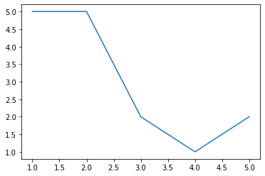

```python
plt.plot(
    [1,2,3,4,5],
    [5,5,2,1,2]
); # the semicolon makes sure I don't get an Out[] in the cell below
```

Open the Core Syntax Lab